# rCharts

## `rCharts`

- `rCharts` is a way to create interactive javascript visualizations using R
- So
  - You don’t have to learn complex tools, like D3
  - You simply work in R learning a minimal amount of new syntax
- `rCharts` was written by Ramnath Vaidyanathan (friend of the Data Science Series), who also wrote slidify, the framework we use for all of the lectures in the class
- This lecture is basically going through (http://ramnathv.github.io/rCharts/)

## Example

```r
require(rCharts)
haireye <- as.data.frame(HairEyeColor)
n1 <- nPlot(Freq ~ Hair, group='Eye', type='multiBarChart',
            data=subset(haireye, Sex=='Male')
)
n1$save('fig/n1.html', cdn=T)
cat('<iframe src="fig/n1.html" width=100%, height=600></iframe>')
```

## nvD3 run

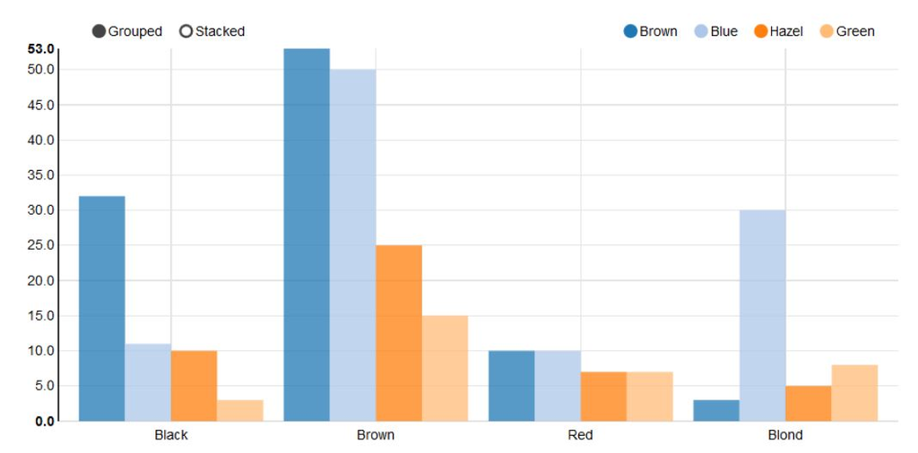

## `slidify` Interactive

- The above was an example of embedding an `rChart` in a `slidify` document
  - In the YAML `yaml ext_widgets : {rCharts: [“libraries/nvd3”]}
- Or, if you use more than one library
- YAML example `yaml ext_widgets : {rCharts: [“libraries/highcharts”, “libraries/nvd3”, “libraries/morris”]}

## Viewing the Plot

- The object `n1` contains the plot
  - In RStudio, typing `n1` brings up the plot in the RStudio viewer (or you can just not assign it to an object)
- Do `n1$` then hit TAB to see the various functions contained in the object
  - `n1$html()` prints out the html for the plot
- I do `n1$save(filename)` then bring the code back into `slidify` document
  - This is recommended for `slidify`, but if you’re just looking at the plot, it’s unnecessary

## Deconstructing Another Example

```r
library(rCharts)
names(iris) = gsub("\\.", "", names(iris))
r1 <- rPlot(SepalLength ~ SepalWidth | Species, data=iris, color='Species',
            type='point')
r1$save('fig/r1.html', cdn=T)
cat('<iframe src="fig/r1.html" width=100% height=600></iframe>')
```

## When Run

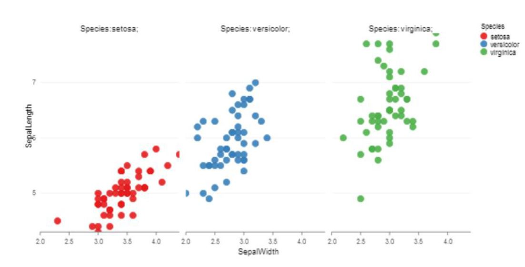

## Excample 2 Facetted Barplot

```r
library(rCharts)
hair_eye <- as.data.frame(HairEyeColor)
r2 <- rPlot(Freq ~ Hair | Eye, color='Eye', data=hair_eye, type='bar')
r2$save('fig/r2.html', cdn=T)
cat('<iframe src="fig/r2.html" width=100% height=600></iframe>')
```

## Example 2 Facetted Barplot, When Run

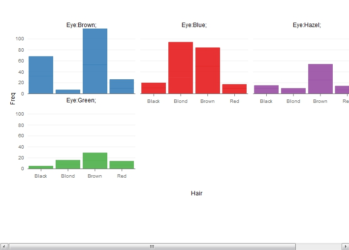

## How to Get the js/html or Publish an `rChart`

Now you can add whatever you’d like

```r
r1 <- rPlot(mpg ~ wt | am + vs, data=mtcars, type="point", color="gear")
r1$print("chart1") # print out the js
r1$save('myPlot.html') # save as an html file
r1$publish('myPlot', host='gist') # save to gist, rjson package required
r1$publish('myPlot', host='rpubs') # save to rpubs
```

## `rCharts` Has Links to Several Libraries

- We’ll do some examples
- Note Ramnath mentions that `io2012` and `polychart` have conflicting js
  - They seem to work for me with that theme, but I get errors if I load he `polychart` library
  - If debugging with `io2012` and `polychart`, factor that in

## `morris`

```r
library(rCharts)
data(economics, package="ggplot2")
econ <- transform(economics, date=as.character(date))
m1 <- mPlot(x="date", y=c("psavert","uempmed"), type="Line", data=econ)
m1$set(pointSize=0, lineWidth=1)
m1$save('fig/m1.html', cdn=T)
cat('<iframe src="fig/m1.html" width=100%, height=600></iframe>')
```

## `morris` Example Run

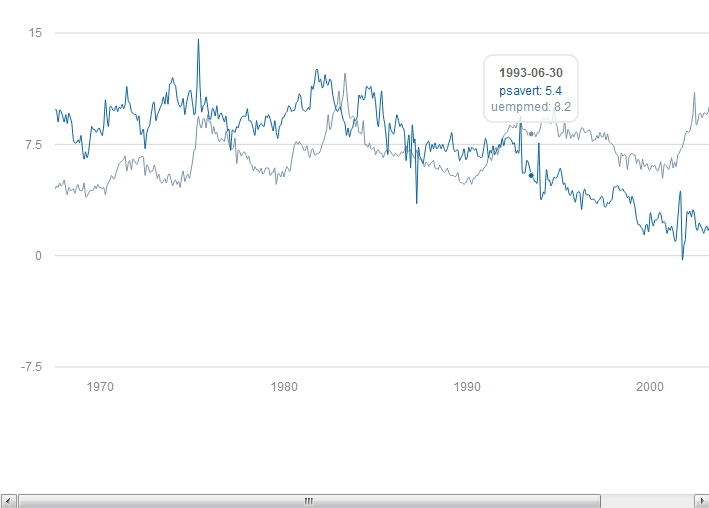

## `xCharts`

```r
library(rCharts)
library(reshape2)
uspexp <- melt(USPersonalExpenditure)
names(uspexp)[1:2] <- c("category","year")
x1 <- xPlot(value ~ year, group="category", data=uspexp, type="line-dotted")
x1$save('fig/x1.html', cdn=T)
cat('<iframe src="fig/x1.html" width=100%, height=600></iframe>')
```

## `xCharts` Run

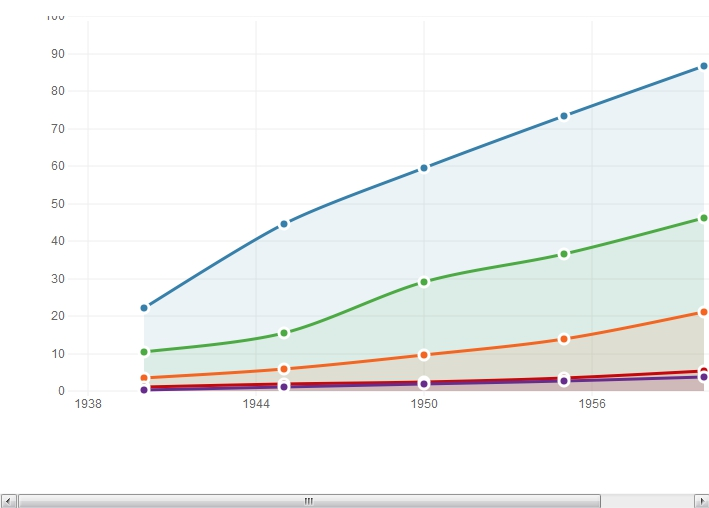

## `Leaflet`

```r
library(rCharts)
map3 <- Leaflet$new()
map3$setView(c(51.505, -0.09), zoom=13)
map3$marker(c(51.5, -0.09), bindPopup="<p> Hi. I am a popup. </p>")
map3$marker(c(51.495, -0.083), bindPopup="<p> Hi. I am another popup. </p>")
map3$save('fig/map3.html', cdn=T)
cat('<iframe src="fig/map3.html" width=100%, height=600></iframe>')
```

## `Leaflet` Run

[figure not shown]

## `Rickshaw`

```r
library(rCharts)
library(reshape2)
usp <- reshape2::melt(USPersonalExpenditure)
# get the decades into a date Rickshaw likes
usp$Var2 <- as.numeric(as.POSIXct(paste0(usp$Var2, "-01-01")))
p4 <- Rickshaw$new()
p4$layer(value ~ Var2, group="Var1", data=usp, type="area", width=560)
# add a helpful slider this easily; other features TRUE as default
p4$set(slider=T)
p4$save('fig/p4.html', cdn=T)
cat('<iframe src="fig/p4.html" width=100%, height=600></iframe>')
```

## `Rickshaw` Run

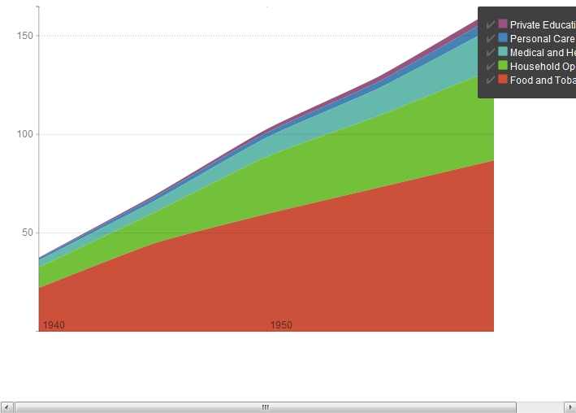

## `highchart`

```r
library(rCharts)
h1 <- hPlot(x="Wr.Hnd", y="NW.Hnd", data=MASS::survey,
            type=c("line","bubble","scatter"), group="Clap",
            size="Age")
h1$save('fig/h1.html', cdn=T)
cat('<iframe src="fig/h1.html" width=100%, height=600></iframe>')
```

## `highchart` Run

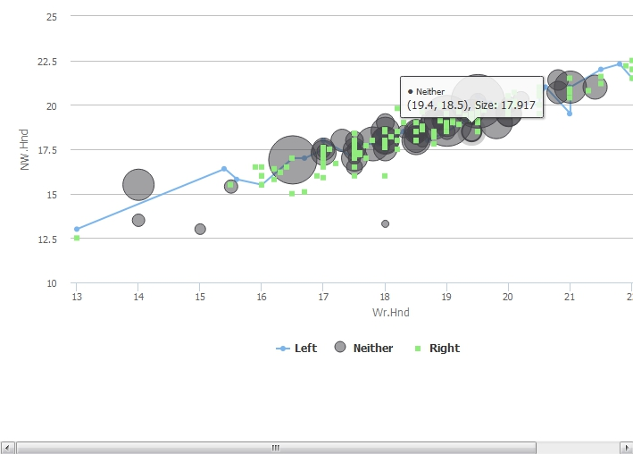

## `rCharts` Summarized

- `rCharts` makes creating interactive javascript visualizations in R ridiculously easy
- However, non-trivial customizationis going to require knowledge of javascript
- If what you want is not too big of a deviation from the `rCharts` examples, then it’s awesome
  - Otherwise, it’s challenging to extend without fairly deep knowledge of the JS libraries that it’s calling
- `rCharts` is under fairly rapid development